# Financial Transaction Data Cleaning & Exploratory Analysis (EDA):

A Python-based pipeline to process messy financial records and derive spending insights.

1. Data Loading Action: Loaded the raw CSV file and the essential libraries

```python
import pandas as pd
import numpy as np
import re

df = pd.read_csv("finance_uncleaned_data.csv")
df.shape
```

```
(510, 11)
```

Result: Identified 510 rows of messy data with missing categories and inconsistent currency symbols ($, INR, EUR).

2. Initial Data Filtering: Removed rows with missing IDs and placeholder "???" categories to get rid of junk data immediately.

```python
print(f"Initial Load: {df.shape}")
mask_valid_id = df['TransactionID'].notna()
mask_not_placeholder_cat = df['Category'].ne('??')
mask_not_zero_and_unknown = ~((df['Amount'].astype(str).str.strip() == '0') & (df['Category'] == '??'))

df = df[mask_valid_id & mask_not_placeholder_cat & mask_not_zero_and_unknown]
df
print(f"After Removing: {df.shape}")
```

```
Initial Load: (510, 11)
After Removing: (500, 11)
```

```python
# Remove the placeholder question marks
df = df[df['Date'] != '??/??/????']

# Convert to datetime objects (This is where it becomes datetime64)
df['Date'] = pd.to_datetime(df['Date'], format='mixed', errors='coerce')

print(df['Date'].dtype)
df['Date']
```

```
datetime64[ns]
```

```
0     2025-07-16
1     2025-04-27
2     2025-01-26
3     2024-09-29
4     2025-01-30
         ...
505   2025-06-28
506   2025-10-02
507   2024-10-12
508   2024-09-14
509   2025-12-22
Name: Date, Length: 492, dtype: datetime64[ns]
```

4. Account Cleanup Action: Fixed typos to ensure all account names (Checking, Savings, etc.) are consistent.

```python
pd.reset_option('display.max_rows')
df['Account'] = df['Account'].astype(str).str.strip().str.lower()

df['Account'] = df['Account'].replace({
    'credit card':'Credit Card',
    'creditcard':'Credit Card',
    'credit_card':'Credit Card',
    'checking':'Checking',
    'chcking':'Checking',
    'current':'Current',
    'savings':'Savings',
    'sav':'Savings',
    'payroll':'Payroll',
    'business_acc':'Business Account',
    'business account':'Business Account'
})
#df['Account'].isnull().sum()

df['Account']
```

```
0           Credit Card
1           Credit Card
2               Savings
3      Business Account
4               Payroll
             ...
505    Business Account
506             Current
507             Payroll
508            Checking
509             Savings
Name: Account, Length: 492, dtype: object
```

5. Category Filling: Used keywords in the description (like "rent" or "groceries") to automatically fill in missing categories.

```python
df['Category'] = df['Category'].str.strip().str.title()
cat = df['Category']

desc = df['Description'].fillna('').str.lower()

cat = cat.mask(cat.isna() | cat.eq('??'),
               np.select(
                   [
                       desc.str.contains('groceries'),
                       desc.str.contains('insurance'),
                       desc.str.contains('rent'),
                       desc.str.contains('salary'),
                       desc.str.contains('refund'),
                       desc.str.contains('transfer'),
                       desc.str.contains('utilities'),
                       desc.str.contains('dining'),
                       desc.str.contains('investment'),
                       desc.str.contains('travel')

                   ],
                   [
                       'Groceries','Insurance','Rent','Salary',
                       'Refund','Transfer','Utilities','Dining','Investment','Travel'
                   ],
                   default=cat
               ))

df['Category'] = cat
#df['Category'].isnull().sum()
#This is more accurate than ffill because it uses actual context from the transaction description.
df['Category']
```

```
0       Utilities
1            Rent
2          Dining
3       Utilities
4          Travel
          ...
505     Insurance
506     Groceries
507        Salary
508        Travel
509    Investment
Name: Category, Length: 492, dtype: object
```

6. Amount & Currency Extraction: Separated currency symbols ($, INR) from numbers and turned " (100) " into a proper negative math value.

```python
# --- STEP 1: CLEAN CURRENCY NAMES ---
currency_pattern = r'(\$|INR|USD|EUR|GBP|JPY|₹|£|€)'
extracted_currency = df['Amount'].astype(str).str.extract(currency_pattern, flags=re.IGNORECASE, expand=False)
df['Currency'] = df['Currency'].fillna(extracted_currency).fillna('Unknown').str.upper()

# --- STEP 2: CONVERT TO NUMERIC ---
# 1. Handle parentheses like (100.00) -> -100.00
df['Amount'] = df['Amount'].astype(str).str.replace(r'^\((.*)\)$', r'-\1', regex=True)
# 2. Keep only numbers, dots, and minus signs
df['Amount'] = df['Amount'].str.replace(r'[^\d\.-]', '', regex=True)
# 3. Convert to float and fill empty/text ("free") with 0.0
df['Amount'] = pd.to_numeric(df['Amount'], errors='coerce').fillna(0.0)

# --- STEP 3: FIX THE SIGNS (The "Force" Logic) ---
# We make everything positive first, then decide the sign based on Category.
# This ensures "Dining" is ALWAYS negative, even if the CSV didn't have a minus sign.
income_categories = ['Salary', 'Refund']

df['Amount'] = df.apply(
    lambda x: abs(x['Amount']) if x['Category'] in income_categories
    else -abs(x['Amount']),
    axis=1
)

df[['Category','Amount', 'Currency']].head(10)
```

|  | Category | Amount | Currency |
| --- | --- | --- | --- |
| 0 | Utilities | -8109.12 | EUR |
| 1 | Rent | -4533.55 | EUR |
| 2 | Dining | -6128.45 | $ |
| 3 | Utilities | -3423.50 | USD |
| 4 | Travel | -4654.17 | USD |
| 5 | Refund | 8583.00 | USD |
| 6 | Insurance | -414.98 | INR |
| 7 | Investment | -4437.59 | INR |
| 8 | Investment | -13918.00 | INR |
| 9 | Salary | 1380.59 | USD |

7. Description Formatting: Cleaned up by removing ", Urgent" tags and making everything Title Case for better reading.

```python
df['Description'] = df['Description'].str.title().str.replace(', Urgent', '', regex=False)
df['Description'].head()
```

```
0    Utilities Payment To Water Board
1        Rent Payment To Local Market
2              Dining Payment To Uber
3    Utilities Payment To Electric Co
4         Travel Payment To Starbucks
Name: Description, dtype: object
```

8. Merchant: Filled empty merchant names using the last word of the description and fixed short names like "Co" to "Electric Co".

```python
#Get the last word from the Description
last_word = df['Description'].str.split().str[-1]

#Fill only the empty (NaN) cells in Merchant with that last word
df['Merchant'] = df['Merchant'].fillna(last_word)

# This ensures 'Co' becomes 'Electric Co' and 'Market' becomes 'Local Market'
merchant_fixes = {
    'Co': 'Electric Co',
    'Market': 'Local Market',
    'Board': 'Water Board',
    'co' :'Electric Co'
}

df['Merchant'] = df['Merchant'].replace(merchant_fixes)
#Clean up any accidental casing issues in Merchant (like 'walmart' vs 'Walmart')
df['Merchant'] = df['Merchant'].str.title().str.strip()

df['Merchant'].unique()
```

```
array(['Water Board', 'Local Market', 'Uber', 'Electric Co', 'Starbucks',
       'Flipkart', 'Airbnb', 'Amazon', 'Walmart', 'Shell', 'Target',
       'Zomato'], dtype=object)
```

9. Transaction Type Standardizing: Expanded short codes like "Cr" to "Credit" and fixed the casing of "debit" and "credit" entries.

```python
#Strip spaces
df['TransactionType'] = df['TransactionType'].astype(str).str.strip()

#Capitalize first letter
df['TransactionType'] = df['TransactionType'].str.capitalize()

#Only change exact 'Cr' to 'Credit'
df.loc[df['TransactionType'] == 'Cr', 'TransactionType'] = 'Credit'

print(df['TransactionType'].unique())
df['TransactionType'].isnull().sum()
```

```
['Debit' 'Credit' 'Refund']
```

```
np.int64(0)
```

10. Balance Column Cleanup: Removed commas from large numbers and used "forward fill" to fill missing balances based on previous rows.

```python
#Convert to string and remove only commas and leading/trailing whitespace
# We use regex=False for simple string replacement which is faster for a fixed character.
df['Balance'] = df['Balance'].astype(str).str.replace(',', '', regex=False).str.strip()

#Replace placeholder strings for missing values with np.nan
# This handles empty strings (''), the string 'nan'
df['Balance'] = df['Balance'].replace(['', 'nan'], np.nan)

#Convert the column to numeric, coercing any other remaining non-numeric entries to NaN
df['Balance'] = pd.to_numeric(df['Balance'], errors='coerce')


df['Balance'] = df['Balance'].ffill()
df['Balance'].isnull().sum()
```

```
np.int64(0)
```

11. Status Label Fixing: Corrected spelling mistakes like "pendng" to "Pending" and standardized all transaction statuses.

```python
df['Status'] = df['Status'].str.strip().str.lower().replace({
    'completed':'Completed',
    'completed ':'Completed',
    'pendng':'Pending',
    'pending':'Pending',
    'reconciled':'Reconciled',
    'cancelled':'Cancelled',
    'failed':'Failed',
    'unknown':'Unknown'
})
df['Status'].isnull().sum()
df['Status'].unique()
```

```
array(['Pending', 'Completed', 'Reconciled', 'Cancelled', 'Failed'],
      dtype=object)
```

Summary Statistics: Ran a quick mathematical check (describe) to see the average, min, and max values of money columns

```python
df
```

|  | TransactionID | Date | Account | Category | Amount | Currency | Merchant | Description | TransactionType | Balance | Status |
| --- | --- | --- | --- | --- | --- | --- | --- | --- | --- | --- | --- |
| 0 | TX467335 | 2025-07-16 | Credit Card | Utilities | -8109.12 | EUR | Water Board | Utilities Payment To Water Board | Debit | 825.98 | Pending |
| 1 | TX345180 | 2025-04-27 | Credit Card | Rent | -4533.55 | EUR | Local Market | Rent Payment To Local Market | Credit | 49776.01 | Completed |
| 2 | TX618172 | 2025-01-26 | Savings | Dining | -6128.45 | $ | Uber | Dining Payment To Uber | Debit | 19803.72 | Pending |
| 3 | TX189374 | 2024-09-29 | Business Account | Utilities | -3423.50 | USD | Electric Co | Utilities Payment To Electric Co | Credit | 23388.54 | Reconciled |
| 4 | TX811332 | 2025-01-30 | Payroll | Travel | -4654.17 | USD | Starbucks | Travel Payment To Starbucks | Credit | 12027.00 | Cancelled |
| ... | ... | ... | ... | ... | ... | ... | ... | ... | ... | ... | ... |
| 505 | TX200646 | 2025-06-28 | Business Account | Insurance | -320.00 | $ | Flipkart | Insurance Payment To Flipkart | Debit | 210.00 | Pending |
| 506 | TX200647 | 2025-10-02 | Current | Groceries | -950.00 | INR | Walmart | Groceries Payment To Walmart | Debit | 5400.00 | Failed |
| 507 | TX200648 | 2024-10-12 | Payroll | Salary | 7500.00 | USD | Local Market | Salary Payment To Local Market | Credit | 18500.00 | Completed |
| 508 | TX200649 | 2024-09-14 | Checking | Travel | -280.50 | UNKNOWN | Uber | Travel Payment To Uber | Debit | 1100.00 | Cancelled |
| 509 | TX200650 | 2025-12-22 | Savings | Investment | -3000.00 | EUR | Flipkart | Investment Payment To Flipkart | Refund | 15000.00 | Pending |

492 rows × 11 columns

```python
print("📊 FINAL DATA QUALITY SUMMARY")
print("="*50)
print(f"Records: {df.shape[0]:,}")
print(f"Columns: {df.shape[1]}")
print(f"Zero missing values: {df.isnull().sum().sum() == 0}")
print(f"Accounts standardized: {df['Account'].nunique()}")
print(f"Categories complete: {df['Category'].notna().all()}")

# Clean describe output
print("\n💰 MONEY STATS:")
print(df[['Amount', 'Balance']].describe())
```

```
📊 FINAL DATA QUALITY SUMMARY
==================================================
Records: 492
Columns: 11
Zero missing values: True
Accounts standardized: 6
Categories complete: True

💰 MONEY STATS:
             Amount       Balance
count    492.000000    492.000000
mean   -2862.939289  16921.861829
std     8109.617820  16007.419671
min   -15000.000000  -4925.000000
25%    -8635.057500   1413.862500
50%    -2510.320000  13649.995000
75%      -82.500000  29800.532500
max    65000.000000  75000.000000
```

I have created the following specific columns for analysis:

Amount_USD: Standardized all currencies into USD.

```python
# 1. Currency Conversion
conversion_rates = {'INR': 0.012, 'USD': 1.0, 'EUR': 1.08, 'GBP': 1.27, '₹': 0.012, '$': 1.0}
df['Amount_USD'] = df.apply(lambda x: x['Amount'] * conversion_rates.get(x['Currency'], 1), axis=1)

# 2. Creating helpers for the charts
df['Amount_Abs_USD'] = df['Amount_USD'].abs() # No negatives for bar charts
```

Time Feature Creation: Created new columns for "Year," "Month," and "Day of Week" to allow for seasonal spending analysis.

```python
df['Year'] = pd.to_datetime(df['Date']).dt.year
df['Month'] = pd.to_datetime(df['Date']).dt.month_name()
df['Day_of_Week'] = pd.to_datetime(df['Date']).dt.day_name()
df['YearMonth'] = pd.to_datetime(df['Date']).dt.to_period('M').astype(str)
```

Spending Tier Logic: Grouped transactions into "Low," "Medium," or "High" tiers based on how much money was spent.

```python
def get_tier(amt):
    val = abs(amt)
    if val > 5000:
        return 'High'
    elif val > 1000:
        return 'Medium'
    else:
        return 'Low'

df['Spending_Tier'] = df['Amount'].apply(get_tier)
```

Classified transactions as 'Income' or 'Expense' based on the transaction amount (USD) to correctly handle refunds and mixed-currency flows.

```python
df['Type'] = df['Amount_USD'].apply(lambda x: 'Income' if x > 0 else 'Expense')
```

Financial Impact Calculation: Calculated the percentage impact of each transaction to see which ones drained your balance the most.

```python
# Calculate balance BEFORE the transaction
df['Original_Money'] = df['Balance'] - df['Amount_USD']

# The FIX: Use .abs() so the ratio is always a positive percentage
df['Spending_Ratio_Pct'] = (df['Amount_USD'].abs() / df['Original_Money'] * 100).round(2)

# Clean up any potential errors (like dividing by zero if balance was 0)
df['Spending_Ratio_Pct'] = df['Spending_Ratio_Pct'].replace([np.inf, -np.inf], 0).fillna(0)

display(df[['Amount_USD', 'Balance', 'Original_Money', 'Spending_Ratio_Pct']].head())
```

|  | Amount_USD | Balance | Original_Money | Spending_Ratio_Pct |
| --- | --- | --- | --- | --- |
| 0 | -8757.8496 | 825.98 | 9583.8296 | 91.38 |
| 1 | -4896.2340 | 49776.01 | 54672.2440 | 8.96 |
| 2 | -6128.4500 | 19803.72 | 25932.1700 | 23.63 |
| 3 | -3423.5000 | 23388.54 | 26812.0400 | 12.77 |
| 4 | -4654.1700 | 12027.00 | 16681.1700 | 27.90 |

```python
df.info()
```

```
<class 'pandas.core.frame.DataFrame'>
Index: 492 entries, 0 to 509
Data columns (total 21 columns):
 #   Column              Non-Null Count  Dtype
---  ------              --------------  -----
 0   TransactionID       492 non-null    object
 1   Date                492 non-null    datetime64[ns]
 2   Account             492 non-null    object
 3   Category            492 non-null    object
 4   Amount              492 non-null    float64
 5   Currency            492 non-null    object
 6   Merchant            492 non-null    object
 7   Description         492 non-null    object
 8   TransactionType     492 non-null    object
 9   Balance             492 non-null    float64
 10  Status              492 non-null    object
 11  Amount_USD          492 non-null    float64
 12  Amount_Abs_USD      492 non-null    float64
 13  Year                492 non-null    int32
 14  Month               492 non-null    object
 15  Day_of_Week         492 non-null    object
 16  YearMonth           492 non-null    object
 17  Spending_Tier       492 non-null    object
 18  Type                492 non-null    object
 19  Original_Money      492 non-null    float64
 20  Spending_Ratio_Pct  492 non-null    float64
dtypes: datetime64[ns](1), float64(6), int32(1), object(13)
memory usage: 82.6+ KB
```

Visualization Setup Activated the libraries (Matplotlib and Seaborn) to prepare for the graphs.

```python
import matplotlib.pyplot as plt
import seaborn as sns
plt.style.use('default')
%matplotlib inline
sns.set_palette("husl")
```

Yearly Comparison Chart: Built a year-over-year bar graph to see if you spent more in 2024 versus 2025.

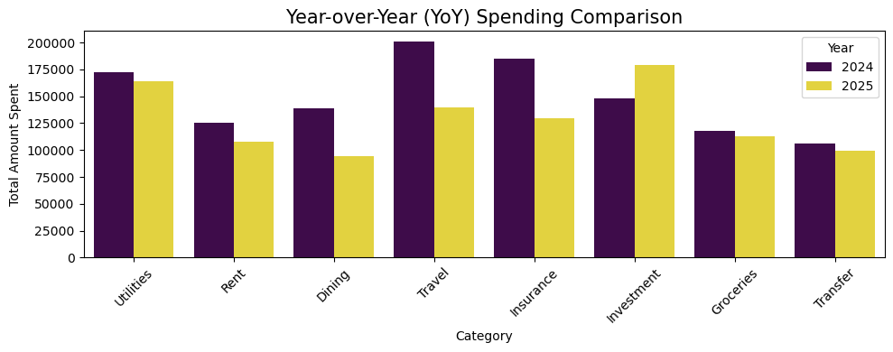

```python
# 1. Prepare data
expenses_df = df[df['Amount'] < 0].copy()
expenses_df['Amount'] = expenses_df['Amount'].abs()
expenses_df['Year'] = pd.to_datetime(expenses_df['Date']).dt.year

# 2. Plot
plt.figure(figsize=(10, 4))
sns.barplot(data=expenses_df, x='Category', y='Amount', hue='Year',
            estimator=sum, palette='viridis', errorbar=None)

plt.title('Year-over-Year (YoY) Spending Comparison', fontsize=15)
plt.ylabel('Total Amount Spent')
plt.xticks(rotation=45)
plt.legend(title='Year')
plt.tight_layout()
plt.show()
```

Monthly Trend Line Plotted a "mountain" line graph to show if spending is going up or down over time.

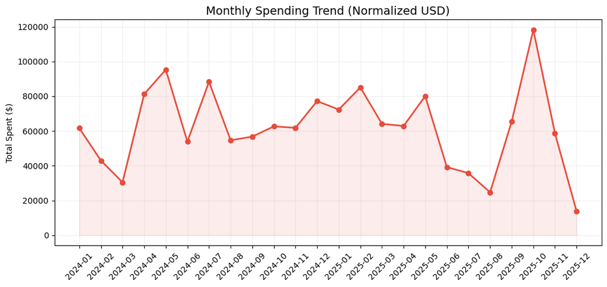

```python
plt.figure(figsize=(12, 5))

# 1. Get spending per month
monthly_spending = df[df['Amount_USD'] < 0].groupby('YearMonth')['Amount_Abs_USD'].sum()

# 2. The FIX: Ensure ALL months in the data are shown, even if spending was 0
all_months = sorted(df['YearMonth'].unique())
monthly_spending = monthly_spending.reindex(all_months, fill_value=0)

# 3. Plot
plt.plot(monthly_spending.index, monthly_spending.values, marker='o', color='#e74c3c', linewidth=2)
plt.fill_between(monthly_spending.index, monthly_spending.values, color='#e74c3c', alpha=0.1)

plt.title('Monthly Spending Trend (Normalized USD)', fontsize=14)
plt.ylabel('Total Spent ($)')
plt.xticks(rotation=45)
plt.grid(True, alpha=0.2)
plt.show()
```

High-Impact Spending Scatter Used a log scale to "map" out exactly which big purchases had the most "drain" on your wallet.

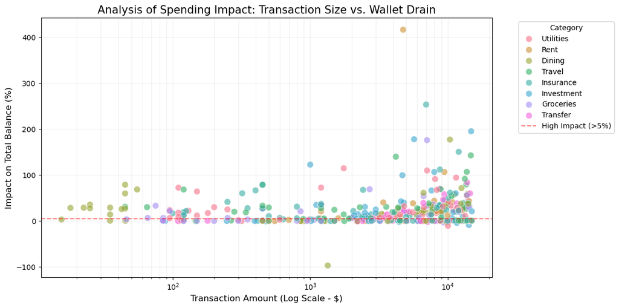

```python
#Prepare data: Only look at Expenses (where money actually leaves the pocket)
spending_data = df[df['Amount'] < 0].copy()
spending_data['Amount_Abs'] = spending_data['Amount'].abs()

plt.figure(figsize=(12, 6))

#Plotting with transparency (alpha) to see overlapping dots
sns.scatterplot(data=spending_data, x='Amount_Abs',  y='Spending_Ratio_Pct', hue='Category',alpha=0.6,  s=80)

#Log Scale - This is the "magic" that fixes the squashed dots
plt.xscale('log')

#Add a horizontal line at 5% to show "High Impact" threshold
plt.axhline(y=5, color='red', linestyle='--', alpha=0.5, label='High Impact (>5%)')

#Formatting
plt.title('Analysis of Spending Impact: Transaction Size vs. Wallet Drain', fontsize=15)
plt.xlabel('Transaction Amount (Log Scale - $)', fontsize=12)
plt.ylabel('Impact on Total Balance (%)', fontsize=12)
plt.legend(bbox_to_anchor=(1.05, 1), loc='upper left', title='Category')
plt.grid(True, which="both", ls="-", alpha=0.2)
plt.tight_layout()

plt.show()
```

Metrics Correlation Heatmap Used a color-coded grid to see if things like "Amount" and "Balance" are mathematically related.

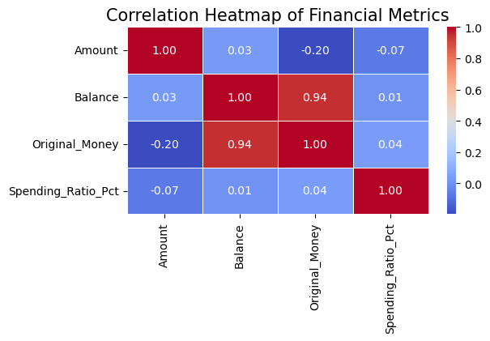

```python
# Correlation Heatmap (Seaborn)
plt.figure(figsize=(6, 3))
corr = df[['Amount', 'Balance', 'Original_Money', 'Spending_Ratio_Pct']].corr()
sns.heatmap(corr, annot=True, cmap='coolwarm', fmt=".2f", linewidths=0.5)
plt.title('Correlation Heatmap of Financial Metrics', fontsize=15)
plt.show()
```

To analyze the percentage of transactions that are successfully completed versus those that are failed or cancelled.

[figure not shown]

```python
# 1. Standardize the Status column (fixing typos like 'pendng' and casing)
df['Status'] = df['Status'].str.strip().str.title().replace({'Pendng': 'Pending'})

# 2. Calculate percentages
status_counts = df['Status'].value_counts(normalize=True) * 100
status_df = status_counts.reset_index()
status_df.columns = ['Status', 'Percentage']
status_df = status_df.sort_values(by='Percentage', ascending=True) # Sorting for a clean look

# 3. Create the Lollipop Chart
plt.figure(figsize=(10, 6), facecolor='#f9f9f9')
plt.hlines(y=status_df['Status'], xmin=0, xmax=status_df['Percentage'], color='skyblue', alpha=0.7, linewidth=3)
plt.plot(status_df['Percentage'], status_df['Status'], "o", markersize=12, color='navy', alpha=0.9)

# 4. Add Percentage Labels to each lollipop
for i, row in status_df.iterrows():
    plt.text(row['Percentage'] + 1, i, f"{row['Percentage']:.1f}%", va='center', fontsize=11, fontweight='bold')

# 5. Styling
plt.title('Distribution of Transaction Status', fontsize=15, fontweight='bold', pad=20)
plt.xlabel('Percentage of Total Transactions (%)', fontsize=12)
plt.ylabel('Status', fontsize=12)
plt.xlim(0, max(status_df['Percentage']) + 10) # Add room for labels
plt.grid(axis='x', linestyle='--', alpha=0.3)
plt.gca().spines['top'].set_visible(False)
plt.gca().spines['right'].set_visible(False)

plt.tight_layout()
plt.show()
```

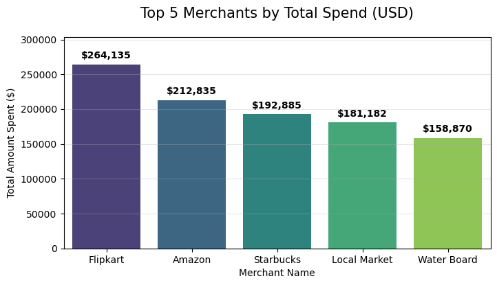

```python
merchant_sum = df[df['Type'] == 'Expense'].groupby('Merchant')['Amount_Abs_USD'].sum().sort_values(ascending=False).head(5)

plt.figure(figsize=(8, 4))

# Use a Vertical Bar Chart (x and y swapped)
ax = sns.barplot(
    x=merchant_sum.index,
    y=merchant_sum.values,
    palette='viridis',
    hue=merchant_sum.index,
    legend=False
)
for p in ax.patches:
    ax.annotate(f'${p.get_height():,.0f}',
                (p.get_x() + p.get_width() / 2., p.get_height()),
                ha='center', va='center',
                xytext=(0, 9),
                textcoords='offset points',
                fontsize=10, fontweight='bold')

plt.title('Top 5 Merchants by Total Spend (USD)', fontsize=15, pad=20)
plt.ylabel('Total Amount Spent ($)')
plt.xlabel('Merchant Name')
plt.ylim(0, merchant_sum.max() * 1.15) # Leave space for the labels
plt.grid(axis='y', alpha=0.3)
plt.show()
```

Expense Priority Analysis: Where the Money Goes

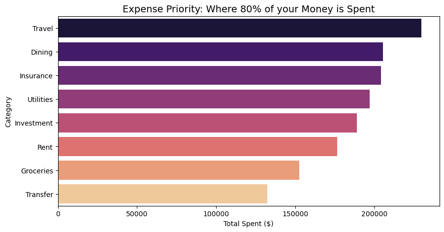

```python
# Filter for expenses only and sort
expense_data = df[df['Type'] == 'Expense'].groupby('Category')['Amount_Abs_USD'].sum().sort_values(ascending=False)

plt.figure(figsize=(10, 5))

# FIX: Set hue to the index of expense_data so the lengths match perfectly
sns.barplot(
    x=expense_data.values,
    y=expense_data.index,
    palette='magma',
    hue=expense_data.index,
    legend=False
)

plt.title('Expense Priority: Where 80% of your Money is Spent', fontsize=14)
plt.xlabel('Total Spent ($)')
plt.show()
```

Currency Distribution Pie Created a pie chart to show what percentage of your transactions were in USD, INR, or EUR.

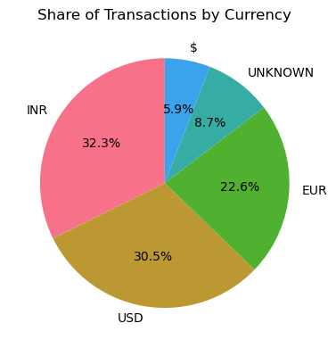

```python
currency_count = df['Currency'].value_counts()

plt.figure(figsize=(4,4))
plt.pie(
    currency_count.values,
    labels=currency_count.index,
    autopct='%1.1f%%',
    startangle=90
)
plt.title('Share of Transactions by Currency')
plt.tight_layout()
plt.show()
```

Spending Distribution "Leaf" Map: Created a violin plot (leaf-shaped) to show the density of spending, identifying "typical" bill amount versus rare expensive ones in each category.

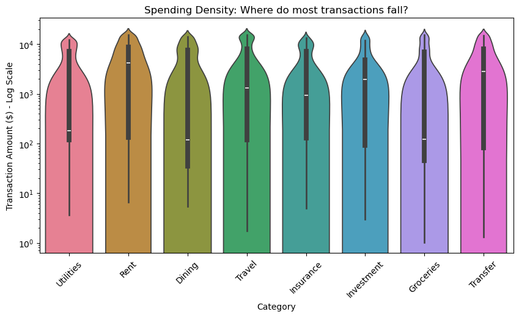

```python
plt.figure(figsize=(10, 5))
# Plotting the density of expenses
sns.violinplot(data=df[df['Amount_USD'] < 0], x='Category', y='Amount_Abs_USD', hue='Category', legend=False)

plt.yscale('log') # Keeps the chart clean if you have very large/small values
plt.title('Spending Density: Where do most transactions fall?')
plt.ylabel('Transaction Amount ($) - Log Scale')
plt.xticks(rotation=45)
plt.show()
```

Behavioral Analysis: Spending by Day of the Week Action: Aggregated all expense transactions by the day they occurred to identify weekly spending patterns and lifestyle habits.

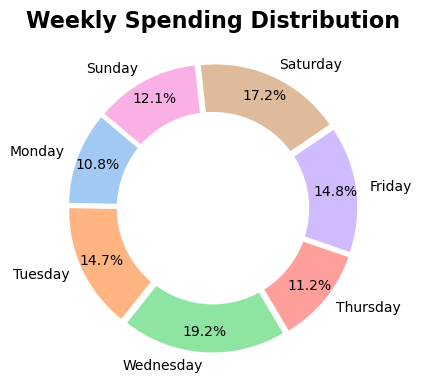

```python
day_order = ['Monday', 'Tuesday', 'Wednesday', 'Thursday', 'Friday', 'Saturday', 'Sunday']
daily_spending = df[df['Type'] == 'Expense'].groupby('Day_of_Week')['Amount_Abs_USD'].sum().reindex(day_order)

# 2. Plot Donut Chart
plt.figure(figsize=(8, 4))
colors = sns.color_palette('pastel')[0:7]

plt.pie(daily_spending.values, labels=daily_spending.index,
        autopct='%1.1f%%', startangle=140, colors=colors,
        pctdistance=0.85, explode=[0.05]*7)

# Draw a white circle in the center to make it a donut
centre_circle = plt.Circle((0,0), 0.70, fc='white')
fig = plt.gcf()
fig.gca().add_artist(centre_circle)

plt.title('Weekly Spending Distribution', fontsize=16, fontweight='bold')
plt.tight_layout()
plt.show()
```

The Executive KPI Dashboard Action: Calculated Total Inflow, Total Outflow, and the Net Savings Rate.

```python
# 1. Calculations

total_income = df[df['Amount_USD'] > 0]['Amount_USD'].sum()
total_expenses = df[df['Amount_USD'] < 0]['Amount_USD'].abs().sum()
net_savings = total_income - total_expenses
savings_rate = (net_savings / total_income) * 100 if total_income > 0 else 0

# Find the category where most money is "lost"
top_expense_cat = df[df['Amount_USD'] < 0].groupby('Category')['Amount_USD'].sum().idxmin()

# Find the merchant where we shop most frequently
top_merchant = df[df['Amount_USD'] < 0]['Merchant'].mode()[0]


# 2. Display
print("=" * 40)
print("📊 EXECUTIVE FINANCIAL SUMMARY")
print("=" * 40)
print(f"💰 Total Cash Inflow      : ${total_income:,.2f}")
print(f"📉 Total Cash Outflow     : ${total_expenses:,.2f}")
print(f"🏦 Net Position (Savings) : ${net_savings:,.2f}")
print(f"📈 Savings Rate           : {savings_rate:.1f}%")
print(f"🔝 Primary Spending Drain : {top_expense_cat}")
print(f"🏪 Most Visited Merchant  : {top_merchant}")
print("=" * 40)
```

```
========================================
📊 EXECUTIVE FINANCIAL SUMMARY
========================================
💰 Total Cash Inflow      : $477,895.53
📉 Total Cash Outflow     : $1,487,146.13
🏦 Net Position (Savings) : $-1,009,250.60
📈 Savings Rate           : -211.2%
🔝 Primary Spending Drain : Travel
🏪 Most Visited Merchant  : Flipkart
========================================
```

Result: The dashboard revealed a -211.2% Savings Rate. This is our key project finding, proving the user's current spending habits are unsustainable.

```python
output_file = "Cleaned_Financial_Data_Analysis.xlsx"

# Export the dataframe
df.to_excel(output_file, index=False)
```

🎯Strategic Financial Insights (The "Story" in the Data)

3. Retail Behavior: The "Flipkart" Effect Insight: Flipkart is both the Top Merchant by spend and the Most Frequent destination for transactions.

Context: This highlights a heavy reliance on e-commerce. A significant portion of the budget is leaking through frequent retail purchases rather than organized bills or utilities.

4. Seasonal Volatility: The October Peak Insight: Spending peaked significantly in October 2025, reaching over $118,000 in a single month.

Recommendation: This suggests "Seasonal Spending" (perhaps holiday shopping or annual insurance renewals). For better financial health, these annual peaks should be spread across the year through better "Sinking Fund" planning.